# LinearRegression Homework

Brian Hallberg

6/19/2018

## Get the data needed

Load the states data. Grab the labels incase we need them later.

```r
states.data <- readRDS("dataSets/states.rds")
states.info <- data.frame(attributes(states.data)[c("names", "var.labels")])
```

## Exercise: least squares regression

────────────────────────────────────────

Use the /states.rds/ data set. Fit a model predicting energy consumed per capita (energy) from the percentage of residents living in metropolitan areas (metro). Be sure to

1. Examine/plot the data before fitting the model
2. Print and interpret the model “summary”
3. “plot” the model to look for deviations from modeling assumptions

Select one or more additional predictors to add to your model and repeat steps 1-3. Is this model significantly better than the model with /metro/ as the only predictor?

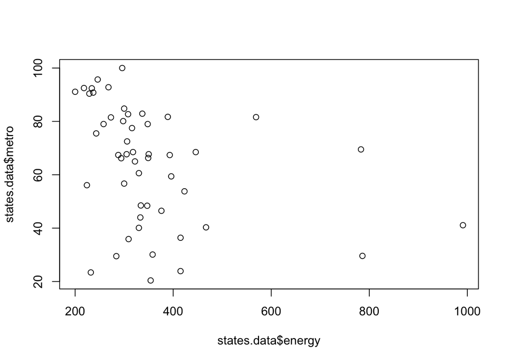

```r
#  1  - Plot the data
plot(states.data$energy, states.data$metro)
```

```r
#  2  - Fit the model
EnergyReg <- lm(energy ~ metro, data = states.data)

# Print Summary of model
summary(EnergyReg)
```

```
##
## Call:
## lm(formula = energy ~ metro, data = states.data)
##
## Residuals:
##     Min      1Q  Median      3Q     Max
## -215.51  -64.54  -30.87   18.71  583.97
##
## Coefficients:
##             Estimate Std. Error t value Pr(>|t|)
## (Intercept) 501.0292    61.8136   8.105 1.53e-10 ***
## metro        -2.2871     0.9139  -2.503   0.0158 *
## ---
## Signif. codes:  0 '***' 0.001 '**' 0.01 '*' 0.05 '.' 0.1 ' ' 1
##
## Residual standard error: 140.2 on 48 degrees of freedom
##   (1 observation deleted due to missingness)
## Multiple R-squared:  0.1154, Adjusted R-squared:  0.097
## F-statistic: 6.263 on 1 and 48 DF,  p-value: 0.01578
```

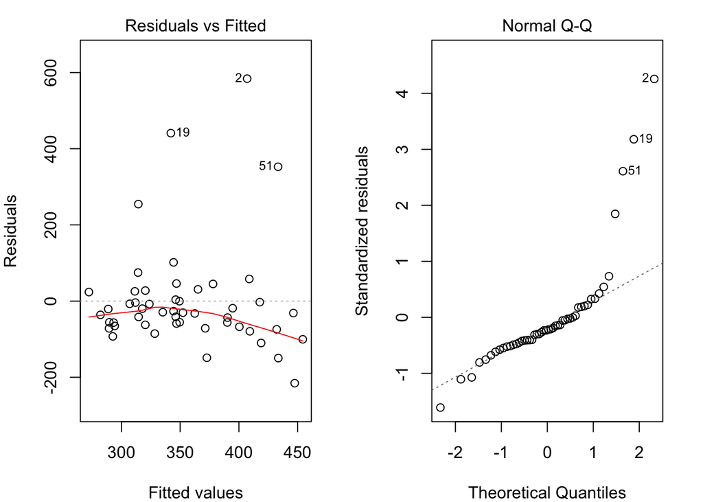

```r
#  3  - look for deviations from model assumptions
par(mar = c(4, 4, 2, 2), mfrow = c(1, 2))
plot(EnergyReg, which = c(1, 2))
```

# Add an other predictor - College

```r
EnergyReg1 <- lm(energy ~ metro + college, data = states.data)
summary(EnergyReg1)
```

```
##
## Call:
## lm(formula = energy ~ metro + college, data = states.data)
##
## Residuals:
##     Min      1Q  Median      3Q     Max
## -187.79  -68.57  -31.92    4.78  602.09
##
## Coefficients:
##             Estimate Std. Error t value Pr(>|t|)
## (Intercept)  555.479    108.991   5.097 6.06e-06 ***
## metro         -2.013      1.024  -1.965   0.0553 .
## college       -3.645      5.991  -0.608   0.5458
## ---
## Signif. codes:  0 '***' 0.001 '**' 0.01 '*' 0.05 '.' 0.1 ' ' 1
##
## Residual standard error: 141.1 on 47 degrees of freedom
##   (1 observation deleted due to missingness)
## Multiple R-squared:  0.1223, Adjusted R-squared:  0.08499
## F-statistic: 3.276 on 2 and 47 DF,  p-value: 0.04658
```

Adding college made very little difference, let’s try a number and see what we learn

```r
EnergyReg2 <- lm(energy ~ metro + density + toxic + green + house + senate, data = states.data)
summary(EnergyReg2)
```

```
##
## Call:
## lm(formula = energy ~ metro + density + toxic + green + house +
##     senate, data = states.data)
##
## Residuals:
##      Min       1Q   Median       3Q      Max
## -185.556  -25.731   -8.841   18.902  183.056
##
## Coefficients:
##              Estimate Std. Error t value Pr(>|t|)
## (Intercept) 160.37302   66.59347   2.408   0.0206 *
## metro         0.47229    0.56536   0.835   0.4083
## density      -0.02385    0.05821  -0.410   0.6842
## toxic         2.50479    0.54450   4.600 4.02e-05 ***
## green         4.80013    0.72007   6.666 4.89e-08 ***
## house         0.16026    0.78029   0.205   0.8383
## senate       -0.29412    0.50991  -0.577   0.5672
## ---
## Signif. codes:  0 '***' 0.001 '**' 0.01 '*' 0.05 '.' 0.1 ' ' 1
##
## Residual standard error: 60.17 on 41 degrees of freedom
##   (3 observations deleted due to missingness)
## Multiple R-squared:  0.7691, Adjusted R-squared:  0.7353
## F-statistic: 22.76 on 6 and 41 DF,  p-value: 1.315e-11
```

That is better, let’s start removing some

```r
EnergyReg3 <- lm(energy ~ metro + density + toxic + green + senate, data = states.data)
summary(EnergyReg3)
```

```
##
## Call:
## lm(formula = energy ~ metro + density + toxic + green + senate,
##     data = states.data)
##
## Residuals:
##      Min       1Q   Median       3Q      Max
## -183.861  -26.932   -5.106   17.533  183.100
##
## Coefficients:
##              Estimate Std. Error t value Pr(>|t|)
## (Intercept) 169.90455   47.21132   3.599 0.000837 ***
## metro         0.42691    0.51443   0.830 0.411301
## density      -0.01918    0.05297  -0.362 0.719152
## toxic         2.48587    0.53050   4.686 2.93e-05 ***
## green         4.72088    0.60100   7.855 8.93e-10 ***
## senate       -0.25214    0.46178  -0.546 0.587944
## ---
## Signif. codes:  0 '***' 0.001 '**' 0.01 '*' 0.05 '.' 0.1 ' ' 1
##
## Residual standard error: 59.48 on 42 degrees of freedom
##   (3 observations deleted due to missingness)
## Multiple R-squared:  0.7688, Adjusted R-squared:  0.7413
## F-statistic: 27.94 on 5 and 42 DF,  p-value: 2.383e-12
```

```r
EnergyReg4 <- lm(energy ~ metro + toxic + green, data = states.data)
summary(EnergyReg4)
```

```
##
## Call:
## lm(formula = energy ~ metro + toxic + green, data = states.data)
##
## Residuals:
##      Min       1Q   Median       3Q      Max
## -179.311  -31.415   -4.114   17.108  191.943
##
## Coefficients:
##             Estimate Std. Error t value Pr(>|t|)
## (Intercept) 160.5506    37.4912   4.282 9.87e-05 ***
## metro         0.2437     0.4273   0.570    0.571
## toxic         2.6691     0.4730   5.643 1.13e-06 ***
## green         4.7992     0.5819   8.247 1.79e-10 ***
## ---
## Signif. codes:  0 '***' 0.001 '**' 0.01 '*' 0.05 '.' 0.1 ' ' 1
##
## Residual standard error: 58.67 on 44 degrees of freedom
##   (3 observations deleted due to missingness)
## Multiple R-squared:  0.7644, Adjusted R-squared:  0.7483
## F-statistic: 47.58 on 3 and 44 DF,  p-value: 7.305e-14
```

Looks like toxic and green are the best predictors.

## Exercise: interactions and factors

────────────────────────────────────────

### Use the states data set.

1. Add on to the regression equation that you created in exercise 1 by generating an interaction term and testing the interaction.
2. Try adding region to the model. Are there significant differences across the four regions?

```r
EnergyReg5 <- lm(energy ~ metro + toxic + green*income, data = states.data)
summary(EnergyReg5)
```

```
##
## Call:
## lm(formula = energy ~ metro + toxic + green * income, data = states.data)
##
## Residuals:
##      Min       1Q   Median       3Q      Max
## -174.450  -27.169   -8.835   14.499  181.574
##
## Coefficients:
##               Estimate Std. Error t value Pr(>|t|)
## (Intercept)  267.63919  127.96801   2.091   0.0426 *
## metro          0.56730    0.56114   1.011   0.3178
## toxic          2.46737    0.52634   4.688 2.91e-05 ***
## green          1.90705    5.37649   0.355   0.7246
## income        -3.79915    4.08462  -0.930   0.3576
## green:income   0.09356    0.17431   0.537   0.5943
## ---
## Signif. codes:  0 '***' 0.001 '**' 0.01 '*' 0.05 '.' 0.1 ' ' 1
##
## Residual standard error: 59.29 on 42 degrees of freedom
##   (3 observations deleted due to missingness)
## Multiple R-squared:  0.7704, Adjusted R-squared:  0.743
## F-statistic: 28.18 on 5 and 42 DF,  p-value: 2.08e-12
```

```r
#Show the results
coef(summary(EnergyReg5))
```

```
##                  Estimate  Std. Error    t value     Pr(>|t|)
## (Intercept)  267.63918700 127.9680134  2.0914538 4.257382e-02
## metro          0.56730412   0.5611368  1.0109907 3.178100e-01
## toxic          2.46736561   0.5263439  4.6877445 2.914569e-05
## green          1.90705437   5.3764918  0.3547024 7.245875e-01
## income        -3.79915135   4.0846185 -0.9301117 3.576287e-01
## green:income   0.09355923   0.1743147  0.5367260 5.942888e-01
```

```r
# make sure R knows region is categorical
states.data$region <- factor(states.data$region)

EnergyReg6 <- lm(energy ~ metro + toxic + green + region, data = states.data)
summary(EnergyReg6)
```

```
##
## Call:
## lm(formula = energy ~ metro + toxic + green + region, data = states.data)
##
## Residuals:
##     Min      1Q  Median      3Q     Max
## -158.30  -23.39  -12.53   17.00  172.54
##
## Coefficients:
##               Estimate Std. Error t value Pr(>|t|)
## (Intercept)   153.6718    42.3815   3.626 0.000788 ***
## metro           0.2914     0.4301   0.678 0.501816
## toxic           2.4238     0.5010   4.838 1.89e-05 ***
## green           4.7999     0.5988   8.016 6.31e-10 ***
## regionN. East -12.3014    28.2791  -0.435 0.665843
## regionSouth    28.4084    23.2879   1.220 0.229482
## regionMidwest   3.7223    24.7604   0.150 0.881239
## ---
## Signif. codes:  0 '***' 0.001 '**' 0.01 '*' 0.05 '.' 0.1 ' ' 1
##
## Residual standard error: 58.71 on 41 degrees of freedom
##   (3 observations deleted due to missingness)
## Multiple R-squared:  0.7802, Adjusted R-squared:  0.748
## F-statistic: 24.26 on 6 and 41 DF,  p-value: 4.909e-12
```

```r
coef(summary(EnergyReg6))
```

```
##                  Estimate Std. Error    t value     Pr(>|t|)
## (Intercept)   153.6718307 42.3814896  3.6259186 7.883017e-04
## metro           0.2914348  0.4300833  0.6776240 5.018163e-01
## toxic           2.4238447  0.5010467  4.8375627 1.888491e-05
## green           4.7999454  0.5987979  8.0159690 6.307599e-10
## regionN. East -12.3014225 28.2790536 -0.4350012 6.658428e-01
## regionSouth    28.4083648 23.2878888  1.2198772 2.294822e-01
## regionMidwest   3.7223053 24.7603578  0.1503333 8.812389e-01
```